# “Simulating co-expression in pre-simulated scRNA-seq data with acorde”

# 3 Introducing co-expression relationships in the simulated dataset

Our co-expression simulation method relies on **breaking the cell-type connectivity between features to rearrange them**. To perform this rearrangement and build new, synthetic features, we require the user to provide **cross-cell type expression patterns**. These patterns are qualitative, i.e. just indicate low or high expression in a given cell type.

If you started at this point, or you want to reproduce the results in our manuscript, load the already-simulated SymSim data object stored within this package:

```r
# load data
data("symsim_sce")

# view object
symsim_sce
```

```
#> class: SingleCellExperiment
#> dim: 8000 1000
#> metadata(0):
#> assays(2): counts logcounts
#> rownames(8000): Feature1 Feature2 ... Feature7999 Feature8000
#> rowData names(0):
#> colnames(1000): Cell1 Cell2 ... Cell999 Cell1000
#> colData names(2): Cell Group
#> reducedDimNames(1): PCA
#> mainExpName: NULL
#> altExpNames(0):
```

```r
# cell type IDs and composition
symsim_sce$Group %>% table()
```

```
#> .
#> Group1 Group2 Group3 Group4 Group5 Group6 Group7 Group8
#>    100    129    129    128    128    129    129    128
```

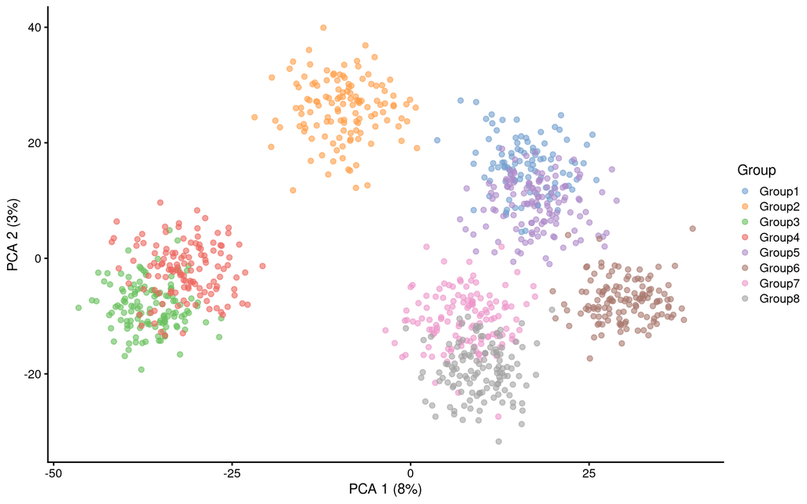

```r
# plot PCA using scater function
plotPCA(symsim_sce, colour_by = "Group")
```

```r
# create cluster patterns
patterns <- tibble(one.a = c(TRUE, rep(FALSE, 7)),
                     one.b = one.a[sample(seq_along(one.a))],
                     one.c = one.b[sample(seq_along(one.b))],
                     one.d = one.c[sample(seq_along(one.c))],
                     one.e = one.d[sample(seq_along(one.d))],
                     two.a = c(rep(TRUE, 2), rep(FALSE, 6)),
                     two.b = two.a[sample(seq_along(two.a))],
                     two.c = two.b[sample(seq_along(two.b))],
                     two.d = two.c[sample(seq_along(two.c))],
                     two.e = two.d[sample(seq_along(two.d))],
                     three.a =  c(rep(TRUE, 3), rep(FALSE, 5)),
                     three.b = three.a[sample(seq_along(three.a))],
                     three.c = three.b[sample(seq_along(three.b))],
                     three.d = three.c[sample(seq_along(three.c))],
                     three.e = three.d[sample(seq_along(three.d))]) %>% t %>% as_tibble()
# show the results
patterns
```

```
#> # A tibble: 15 × 8
#>    V1    V2    V3    V4    V5    V6    V7    V8
#>    <lgl> <lgl> <lgl> <lgl> <lgl> <lgl> <lgl> <lgl>
#>  1 TRUE  FALSE FALSE FALSE FALSE FALSE FALSE FALSE
#>  2 FALSE FALSE TRUE  FALSE FALSE FALSE FALSE FALSE
#>  3 FALSE FALSE TRUE  FALSE FALSE FALSE FALSE FALSE
#>  4 FALSE FALSE FALSE FALSE FALSE FALSE TRUE  FALSE
#>  5 FALSE FALSE FALSE FALSE FALSE FALSE FALSE TRUE
#>  6 TRUE  TRUE  FALSE FALSE FALSE FALSE FALSE FALSE
#>  7 FALSE FALSE TRUE  TRUE  FALSE FALSE FALSE FALSE
#>  8 FALSE FALSE FALSE FALSE FALSE TRUE  FALSE TRUE
#>  9 FALSE FALSE FALSE TRUE  FALSE FALSE TRUE  FALSE
#> 10 FALSE FALSE FALSE TRUE  FALSE FALSE FALSE TRUE
#> 11 TRUE  TRUE  TRUE  FALSE FALSE FALSE FALSE FALSE
#> 12 FALSE FALSE TRUE  TRUE  FALSE FALSE FALSE TRUE
#> 13 FALSE FALSE TRUE  FALSE FALSE TRUE  TRUE  FALSE
#> 14 FALSE FALSE TRUE  FALSE FALSE TRUE  FALSE TRUE
#> 15 FALSE FALSE FALSE TRUE  FALSE TRUE  FALSE TRUE
```

Now, we are ready to run the function in acorde to generate the selected co-expression patterns in the already-simulated dataset:

```r
coexpr_results <- simulate_coexpression(symsim_sce,
                                        feature_no = 1400,
                                        patterns,
                                        cluster_size = 200)

names(coexpr_results)
```

```
#> [1] "sim_matrix"   "sim_clusters"
```

As a result, we obtain a named list including the expression matrix and the feature IDs that go into each of the 15 clusters.

```r
# show expression matrix
coexpr_results$sim_matrix
```

```
#> # A tibble: 3,000 × 1,001
#>    feature   Cell1 Cell2 Cell3 Cell4 Cell5 Cell6 Cell7 Cell8 Cell9 Cell10 Cell11
#>    <chr>     <int> <int> <int> <int> <int> <int> <int> <int> <int>  <int>  <int>
#>  1 Feature1    232   530   206   787   108   160   113   627   311    281    482
#>  2 Feature2    595   705   875   214   396   706   141   216   676    314    691
#>  3 Feature3   1698  2458  2446  2342  2223  1637  2179  1865  2272   2054   1950
#>  4 Feature4    313   219   421   219   213   228   178   103   315    284    169
#>  5 Feature5   2452  5060  4800  3613  3126  2042  3378  4482   145   3087   4825
#>  6 Feature6    262   481   659   651   356    27   605   208   124     40    282
#>  7 Feature7      0  1069   741  1226  1525    56   903  1895     0      0   1793
#>  8 Feature8   1973  2998  2713  2419  2419  2438  1580  2569  3061   2353   2615
#>  9 Feature9    225   649   777    92   334   195   183   593  1165    272    869
#> 10 Feature10  1224  2353   897  1662  2673  2572  1894  2837  2173   2178   1745
#> # … with 2,990 more rows, and 989 more variables: Cell12 <int>, Cell13 <int>,
#> #   Cell14 <int>, Cell15 <int>, Cell16 <int>, Cell17 <int>, Cell18 <int>,
#> #   Cell19 <int>, Cell20 <int>, Cell21 <int>, Cell22 <int>, Cell23 <int>,
#> #   Cell24 <int>, Cell25 <int>, Cell26 <int>, Cell27 <int>, Cell28 <int>,
#> #   Cell29 <int>, Cell30 <int>, Cell31 <int>, Cell32 <int>, Cell33 <int>,
#> #   Cell34 <int>, Cell35 <int>, Cell36 <int>, Cell37 <int>, Cell38 <int>,
#> #   Cell39 <int>, Cell40 <int>, Cell41 <int>, Cell42 <int>, Cell43 <int>, …
```

```r
# show summary of clusters
map_int(coexpr_results$sim_clusters, length)
```

```
#>   1   2   3   4   5   6   7   8   9  10  11  12  13  14  15
#> 200 200 200 200 200 200 200 200 200 200 200 200 200 200 200
```

# 4 Visualizing the simulated co-expression patterns

Now, we can use some of the visualization functions to make sure that our data contains the specified patterns:

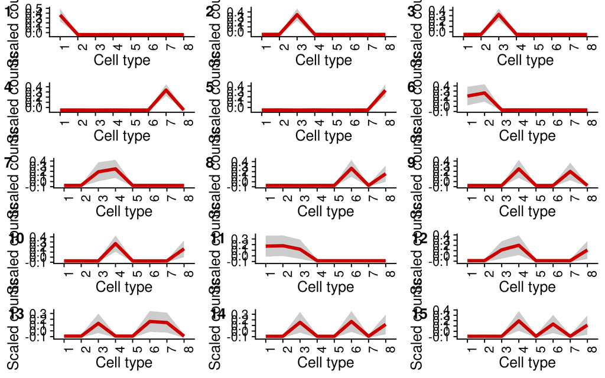

```r
# scale the matrix to enhance visualization
coexpr.scaled <- scale_isoforms(coexpr_results$sim_matrix,
                                isoform_col = "feature")

# create cell-to-cell-type ID table
ct <- colData(symsim_sce) %>%
  as_tibble %>%
  rename(cell = "Cell", cell_type = "Group")

# compute average-by-cell type cluster patterns
cluster_patterns <- map(coexpr_results$sim_clusters,
                    ~calculate_cluster_profile(coexpr.scaled,
                                               isoform_ids = .,
                                               id_table = ct,
                                               isoform_col = "feature"))

# plot patterns
library(cowplot)
theme_set(theme_cowplot())

pattern_plots <- map(cluster_patterns,
                     plot_cluster_profile,
                     ct_labels = seq(1, 8))

plot_grid(plotlist = pattern_plots,
          labels = seq(1, 15),
          ncol = 3)
```